# Risk Factor Analysis

## Outcome Variable

**Outcome Variable:** wasted

## Predictor Variables

**Intervention Variable:** impsan

**Adjustment Set:**

unadjusted

## Stratifying Variables

The analysis was stratified on these variable(s):

- agecat
- studyid
- country

## Data Summary

| agecat | studyid | country | impsan | wasted | n_cell | n |
| --- | --- | --- | --- | --- | --- | --- |
| Birth | ki0047075b-MAL-ED | BANGLADESH | 0 | 0 | 32 | 222 |
| Birth | ki0047075b-MAL-ED | BANGLADESH | 0 | 1 | 4 | 222 |
| Birth | ki0047075b-MAL-ED | BANGLADESH | 1 | 0 | 152 | 222 |
| Birth | ki0047075b-MAL-ED | BANGLADESH | 1 | 1 | 34 | 222 |
| Birth | ki0047075b-MAL-ED | BRAZIL | 0 | 0 | 3 | 167 |
| Birth | ki0047075b-MAL-ED | BRAZIL | 0 | 1 | 1 | 167 |
| Birth | ki0047075b-MAL-ED | BRAZIL | 1 | 0 | 158 | 167 |
| Birth | ki0047075b-MAL-ED | BRAZIL | 1 | 1 | 5 | 167 |
| Birth | ki0047075b-MAL-ED | INDIA | 0 | 0 | 86 | 188 |
| Birth | ki0047075b-MAL-ED | INDIA | 0 | 1 | 12 | 188 |
| Birth | ki0047075b-MAL-ED | INDIA | 1 | 0 | 72 | 188 |
| Birth | ki0047075b-MAL-ED | INDIA | 1 | 1 | 18 | 188 |
| Birth | ki0047075b-MAL-ED | NEPAL | 0 | 0 | 1 | 166 |
| Birth | ki0047075b-MAL-ED | NEPAL | 0 | 1 | 0 | 166 |
| Birth | ki0047075b-MAL-ED | NEPAL | 1 | 0 | 145 | 166 |
| Birth | ki0047075b-MAL-ED | NEPAL | 1 | 1 | 20 | 166 |
| Birth | ki0047075b-MAL-ED | PERU | 0 | 0 | 179 | 243 |
| Birth | ki0047075b-MAL-ED | PERU | 0 | 1 | 4 | 243 |
| Birth | ki0047075b-MAL-ED | PERU | 1 | 0 | 60 | 243 |
| Birth | ki0047075b-MAL-ED | PERU | 1 | 1 | 0 | 243 |
| Birth | ki0047075b-MAL-ED | SOUTH AFRICA | 0 | 0 | 196 | 211 |
| Birth | ki0047075b-MAL-ED | SOUTH AFRICA | 0 | 1 | 13 | 211 |
| Birth | ki0047075b-MAL-ED | SOUTH AFRICA | 1 | 0 | 2 | 211 |
| Birth | ki0047075b-MAL-ED | SOUTH AFRICA | 1 | 1 | 0 | 211 |
| Birth | ki0047075b-MAL-ED | TANZANIA, UNITED REPUBLIC OF | 0 | 0 | 107 | 109 |
| Birth | ki0047075b-MAL-ED | TANZANIA, UNITED REPUBLIC OF | 0 | 1 | 2 | 109 |
| Birth | ki0047075b-MAL-ED | TANZANIA, UNITED REPUBLIC OF | 1 | 0 | 0 | 109 |
| Birth | ki0047075b-MAL-ED | TANZANIA, UNITED REPUBLIC OF | 1 | 1 | 0 | 109 |
| Birth | ki1017093-NIH-Birth | BANGLADESH | 0 | 0 | 15 | 28 |
| Birth | ki1017093-NIH-Birth | BANGLADESH | 0 | 1 | 4 | 28 |

[output cut: 166 more lines]

The following strata were considered:

- agecat: 24 months, studyid: ki0047075b-MAL-ED, country: BANGLADESH
- agecat: 24 months, studyid: ki0047075b-MAL-ED, country: BRAZIL
- agecat: 24 months, studyid: ki0047075b-MAL-ED, country: INDIA
- agecat: 24 months, studyid: ki0047075b-MAL-ED, country: NEPAL
- agecat: 24 months, studyid: ki0047075b-MAL-ED, country: PERU
- agecat: 24 months, studyid: ki0047075b-MAL-ED, country: SOUTH AFRICA
- agecat: 24 months, studyid: ki0047075b-MAL-ED, country: TANZANIA, UNITED REPUBLIC OF
- agecat: 24 months, studyid: ki1017093-NIH-Birth, country: BANGLADESH
- agecat: 24 months, studyid: ki1017093b-PROVIDE, country: BANGLADESH
- agecat: 24 months, studyid: ki1017093c-NIH-Crypto, country: BANGLADESH
- agecat: 24 months, studyid: ki1114097-CONTENT, country: PERU
- agecat: 24 months, studyid: ki1135781-COHORTS, country: GUATEMALA
- agecat: 24 months, studyid: ki1135781-COHORTS, country: INDIA
- agecat: 24 months, studyid: ki1135781-COHORTS, country: PHILIPPINES
- agecat: 24 months, studyid: ki1148112-LCNI-5, country: MALAWI
- agecat: 24 months, studyid: kiGH5241-JiVitA-3, country: BANGLADESH
- agecat: 24 months, studyid: kiGH5241-JiVitA-4, country: BANGLADESH
- agecat: 6 months, studyid: ki0047075b-MAL-ED, country: BANGLADESH
- agecat: 6 months, studyid: ki0047075b-MAL-ED, country: BRAZIL
- agecat: 6 months, studyid: ki0047075b-MAL-ED, country: INDIA
- agecat: 6 months, studyid: ki0047075b-MAL-ED, country: NEPAL
- agecat: 6 months, studyid: ki0047075b-MAL-ED, country: PERU
- agecat: 6 months, studyid: ki0047075b-MAL-ED, country: SOUTH AFRICA
- agecat: 6 months, studyid: ki0047075b-MAL-ED, country: TANZANIA, UNITED REPUBLIC OF
- agecat: 6 months, studyid: ki1017093-NIH-Birth, country: BANGLADESH
- agecat: 6 months, studyid: ki1017093b-PROVIDE, country: BANGLADESH
- agecat: 6 months, studyid: ki1017093c-NIH-Crypto, country: BANGLADESH
- agecat: 6 months, studyid: ki1114097-CONTENT, country: PERU
- agecat: 6 months, studyid: ki1135781-COHORTS, country: GUATEMALA
- agecat: 6 months, studyid: ki1135781-COHORTS, country: INDIA
- agecat: 6 months, studyid: ki1135781-COHORTS, country: PHILIPPINES
- agecat: 6 months, studyid: ki1148112-LCNI-5, country: MALAWI
- agecat: 6 months, studyid: kiGH5241-JiVitA-3, country: BANGLADESH
- agecat: 6 months, studyid: kiGH5241-JiVitA-4, country: BANGLADESH
- agecat: Birth, studyid: ki0047075b-MAL-ED, country: BANGLADESH
- agecat: Birth, studyid: ki0047075b-MAL-ED, country: BRAZIL
- agecat: Birth, studyid: ki0047075b-MAL-ED, country: INDIA
- agecat: Birth, studyid: ki0047075b-MAL-ED, country: NEPAL
- agecat: Birth, studyid: ki0047075b-MAL-ED, country: PERU
- agecat: Birth, studyid: ki0047075b-MAL-ED, country: SOUTH AFRICA
- agecat: Birth, studyid: ki0047075b-MAL-ED, country: TANZANIA, UNITED REPUBLIC OF
- agecat: Birth, studyid: ki1017093-NIH-Birth, country: BANGLADESH
- agecat: Birth, studyid: ki1017093c-NIH-Crypto, country: BANGLADESH
- agecat: Birth, studyid: ki1114097-CONTENT, country: PERU
- agecat: Birth, studyid: ki1135781-COHORTS, country: GUATEMALA
- agecat: Birth, studyid: ki1135781-COHORTS, country: INDIA
- agecat: Birth, studyid: ki1135781-COHORTS, country: PHILIPPINES
- agecat: Birth, studyid: kiGH5241-JiVitA-3, country: BANGLADESH
- agecat: Birth, studyid: kiGH5241-JiVitA-4, country: BANGLADESH

### Dropped Strata

Some strata were dropped due to rare outcomes:

- agecat: Birth, studyid: ki0047075b-MAL-ED, country: BANGLADESH
- agecat: Birth, studyid: ki0047075b-MAL-ED, country: BRAZIL
- agecat: Birth, studyid: ki0047075b-MAL-ED, country: NEPAL
- agecat: Birth, studyid: ki0047075b-MAL-ED, country: PERU
- agecat: Birth, studyid: ki0047075b-MAL-ED, country: SOUTH AFRICA
- agecat: Birth, studyid: ki0047075b-MAL-ED, country: TANZANIA, UNITED REPUBLIC OF
- agecat: Birth, studyid: ki1017093-NIH-Birth, country: BANGLADESH
- agecat: Birth, studyid: ki1017093c-NIH-Crypto, country: BANGLADESH
- agecat: Birth, studyid: ki1114097-CONTENT, country: PERU
- agecat: 6 months, studyid: ki0047075b-MAL-ED, country: BANGLADESH
- agecat: 6 months, studyid: ki0047075b-MAL-ED, country: BRAZIL
- agecat: 6 months, studyid: ki0047075b-MAL-ED, country: NEPAL
- agecat: 6 months, studyid: ki0047075b-MAL-ED, country: PERU
- agecat: 6 months, studyid: ki0047075b-MAL-ED, country: SOUTH AFRICA
- agecat: 6 months, studyid: ki0047075b-MAL-ED, country: TANZANIA, UNITED REPUBLIC OF
- agecat: 6 months, studyid: ki1017093b-PROVIDE, country: BANGLADESH
- agecat: 6 months, studyid: ki1114097-CONTENT, country: PERU
- agecat: 6 months, studyid: ki1135781-COHORTS, country: GUATEMALA
- agecat: 6 months, studyid: ki1135781-COHORTS, country: PHILIPPINES
- agecat: 6 months, studyid: ki1148112-LCNI-5, country: MALAWI
- agecat: 24 months, studyid: ki0047075b-MAL-ED, country: BRAZIL
- agecat: 24 months, studyid: ki0047075b-MAL-ED, country: NEPAL
- agecat: 24 months, studyid: ki0047075b-MAL-ED, country: PERU
- agecat: 24 months, studyid: ki0047075b-MAL-ED, country: SOUTH AFRICA
- agecat: 24 months, studyid: ki0047075b-MAL-ED, country: TANZANIA, UNITED REPUBLIC OF
- agecat: 24 months, studyid: ki1017093b-PROVIDE, country: BANGLADESH
- agecat: 24 months, studyid: ki1017093c-NIH-Crypto, country: BANGLADESH
- agecat: 24 months, studyid: ki1114097-CONTENT, country: PERU
- agecat: 24 months, studyid: ki1135781-COHORTS, country: GUATEMALA
- agecat: 24 months, studyid: ki1148112-LCNI-5, country: MALAWI

## Methods Detail

We’re interested in the causal parameters $E[Y_a]$ for all values of $a \in \mathcal{A}$. These parameters represent the mean outcome if, possibly contrary to fact, we intervened to set all units to have $A=a$. Under the randomization and positivity assumptions, these are identified by the statistical parameters $\psi_a=E_W[E_{Y|A,W}(Y|A=a,W)]$. In addition, we’re interested in the mean of $Y$, $E[Y]$ under no intervention (the observed mean). We will estimate these parameters by using SuperLearner to fit the relevant likelihood factors – $E_{Y|A,W}(Y|A=a,W)$ and $p(A=a|W)$, and then updating our likelihood fit using a joint TMLE.

For unadjusted analyses ($W=\{\}$), initial likelihoods were estimated using Lrnr_glm to estimate the simple $E(Y|A)$ and Lrnr_mean to estimate $p(A)$. For adjusted analyses, a small library containing Lrnr_glmnet, Lrnr_xgboost, and Lrnr_mean was used.

Having estimated these parameters, we will then use the delta method to estimate relative risks and attributable risks relative to a prespecified baseline level of $A$.

# Results Detail

## Results Plots

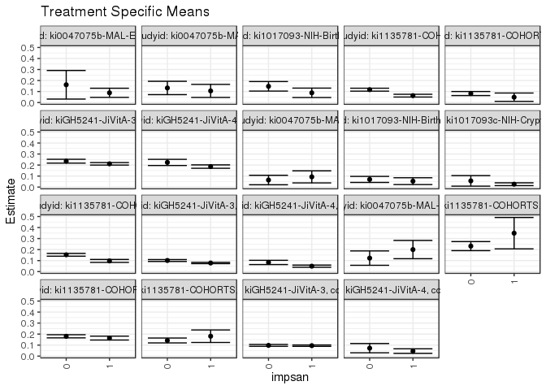

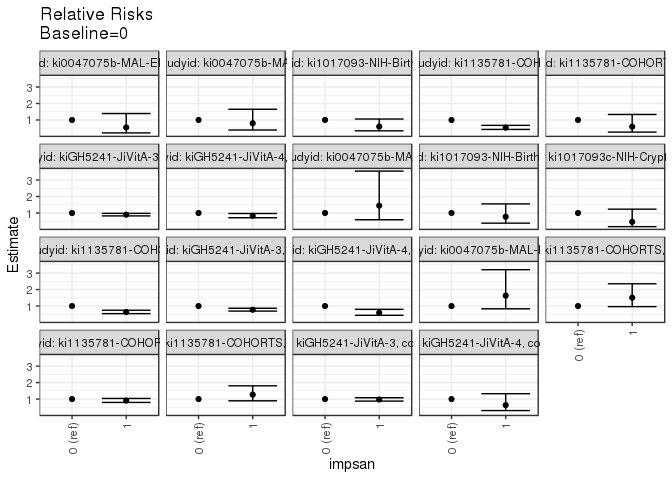

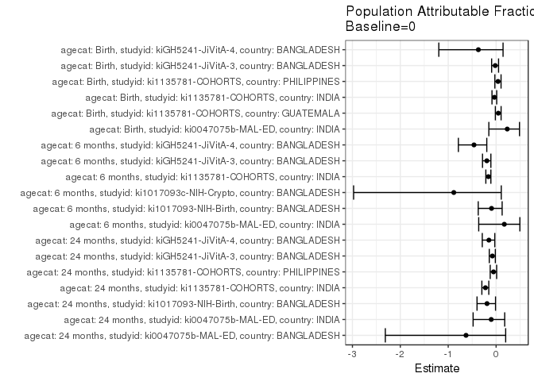

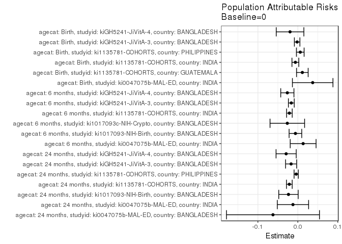

## Results Table

### Parameter: TSM

| agecat | studyid | country | intervention_level | baseline_level | estimate | ci_lower | ci_upper |
| --- | --- | --- | --- | --- | --- | --- | --- |
| Birth | ki0047075b-MAL-ED | INDIA | 0 | NA | 0.1224490 | 0.0573751 | 0.1875229 |
| Birth | ki0047075b-MAL-ED | INDIA | 1 | NA | 0.2000000 | 0.1171400 | 0.2828600 |
| Birth | ki1135781-COHORTS | GUATEMALA | 0 | NA | 0.2315271 | 0.1904514 | 0.2726027 |
| Birth | ki1135781-COHORTS | GUATEMALA | 1 | NA | 0.3488372 | 0.2062258 | 0.4914486 |
| Birth | ki1135781-COHORTS | INDIA | 0 | NA | 0.1801153 | 0.1658185 | 0.1944121 |
| Birth | ki1135781-COHORTS | INDIA | 1 | NA | 0.1637982 | 0.1461254 | 0.1814711 |
| Birth | ki1135781-COHORTS | PHILIPPINES | 0 | NA | 0.1422550 | 0.1200208 | 0.1644892 |
| Birth | ki1135781-COHORTS | PHILIPPINES | 1 | NA | 0.1807910 | 0.1240705 | 0.2375115 |
| Birth | kiGH5241-JiVitA-3 | BANGLADESH | 0 | NA | 0.0976838 | 0.0891701 | 0.1061975 |
| Birth | kiGH5241-JiVitA-3 | BANGLADESH | 1 | NA | 0.0951138 | 0.0889034 | 0.1013242 |
| Birth | kiGH5241-JiVitA-4 | BANGLADESH | 0 | NA | 0.0722222 | 0.0299878 | 0.1144566 |
| Birth | kiGH5241-JiVitA-4 | BANGLADESH | 1 | NA | 0.0457256 | 0.0248970 | 0.0665543 |
| 6 months | ki0047075b-MAL-ED | INDIA | 0 | NA | 0.0640000 | 0.0210013 | 0.1069987 |
| 6 months | ki0047075b-MAL-ED | INDIA | 1 | NA | 0.0925926 | 0.0378079 | 0.1473773 |
| 6 months | ki1017093-NIH-Birth | BANGLADESH | 0 | NA | 0.0694864 | 0.0420675 | 0.0969054 |
| 6 months | ki1017093-NIH-Birth | BANGLADESH | 1 | NA | 0.0536585 | 0.0227826 | 0.0845345 |
| 6 months | ki1017093c-NIH-Crypto | BANGLADESH | 0 | NA | 0.0561798 | 0.0083061 | 0.1040534 |
| 6 months | ki1017093c-NIH-Crypto | BANGLADESH | 1 | NA | 0.0260163 | 0.0134265 | 0.0386060 |
| 6 months | ki1135781-COHORTS | INDIA | 0 | NA | 0.1526742 | 0.1399810 | 0.1653675 |
| 6 months | ki1135781-COHORTS | INDIA | 1 | NA | 0.0968600 | 0.0834855 | 0.1102346 |
| 6 months | kiGH5241-JiVitA-3 | BANGLADESH | 0 | NA | 0.1008827 | 0.0921151 | 0.1096504 |
| 6 months | kiGH5241-JiVitA-3 | BANGLADESH | 1 | NA | 0.0780691 | 0.0724511 | 0.0836870 |
| 6 months | kiGH5241-JiVitA-4 | BANGLADESH | 0 | NA | 0.0832571 | 0.0640503 | 0.1024639 |
| 6 months | kiGH5241-JiVitA-4 | BANGLADESH | 1 | NA | 0.0492769 | 0.0394688 | 0.0590851 |
| 24 months | ki0047075b-MAL-ED | BANGLADESH | 0 | NA | 0.1612903 | 0.0315115 | 0.2910692 |
| 24 months | ki0047075b-MAL-ED | BANGLADESH | 1 | NA | 0.0883978 | 0.0469445 | 0.1298511 |
| 24 months | ki0047075b-MAL-ED | INDIA | 0 | NA | 0.1322314 | 0.0717402 | 0.1927226 |
| 24 months | ki0047075b-MAL-ED | INDIA | 1 | NA | 0.1057692 | 0.0465309 | 0.1650076 |
| 24 months | ki1017093-NIH-Birth | BANGLADESH | 0 | NA | 0.1472868 | 0.1039926 | 0.1905810 |
| 24 months | ki1017093-NIH-Birth | BANGLADESH | 1 | NA | 0.0882353 | 0.0455484 | 0.1309221 |
| 24 months | ki1135781-COHORTS | INDIA | 0 | NA | 0.1168946 | 0.1036669 | 0.1301223 |
| 24 months | ki1135781-COHORTS | INDIA | 1 | NA | 0.0624571 | 0.0500302 | 0.0748840 |
| 24 months | ki1135781-COHORTS | PHILIPPINES | 0 | NA | 0.0817031 | 0.0634823 | 0.0999239 |
| 24 months | ki1135781-COHORTS | PHILIPPINES | 1 | NA | 0.0483871 | 0.0105994 | 0.0861748 |
| 24 months | kiGH5241-JiVitA-3 | BANGLADESH | 0 | NA | 0.2348485 | 0.2174895 | 0.2522075 |
| 24 months | kiGH5241-JiVitA-3 | BANGLADESH | 1 | NA | 0.2110107 | 0.1998355 | 0.2221859 |
| 24 months | kiGH5241-JiVitA-4 | BANGLADESH | 0 | NA | 0.2237960 | 0.1958688 | 0.2517233 |
| 24 months | kiGH5241-JiVitA-4 | BANGLADESH | 1 | NA | 0.1860528 | 0.1707601 | 0.2013456 |

### Parameter: E(Y)

| agecat | studyid | country | intervention_level | baseline_level | estimate | ci_lower | ci_upper |
| --- | --- | --- | --- | --- | --- | --- | --- |
| Birth | ki0047075b-MAL-ED | INDIA | NA | NA | 0.1595745 | 0.1070866 | 0.2120623 |
| Birth | ki1135781-COHORTS | GUATEMALA | NA | NA | 0.2427617 | 0.2030594 | 0.2824640 |
| Birth | ki1135781-COHORTS | INDIA | NA | NA | 0.1739520 | 0.1628271 | 0.1850770 |
| Birth | ki1135781-COHORTS | PHILIPPINES | NA | NA | 0.1483126 | 0.1275443 | 0.1690809 |
| Birth | kiGH5241-JiVitA-3 | BANGLADESH | NA | NA | 0.0959271 | 0.0907227 | 0.1011315 |
| Birth | kiGH5241-JiVitA-4 | BANGLADESH | NA | NA | 0.0527086 | 0.0336587 | 0.0717585 |
| 6 months | ki0047075b-MAL-ED | INDIA | NA | NA | 0.0772532 | 0.0428971 | 0.1116093 |
| 6 months | ki1017093-NIH-Birth | BANGLADESH | NA | NA | 0.0634328 | 0.0427791 | 0.0840865 |
| 6 months | ki1017093c-NIH-Crypto | BANGLADESH | NA | NA | 0.0298295 | 0.0172543 | 0.0424048 |
| 6 months | ki1135781-COHORTS | INDIA | NA | NA | 0.1315471 | 0.1221436 | 0.1409506 |
| 6 months | kiGH5241-JiVitA-3 | BANGLADESH | NA | NA | 0.0845406 | 0.0797299 | 0.0893513 |
| 6 months | kiGH5241-JiVitA-4 | BANGLADESH | NA | NA | 0.0569712 | 0.0481278 | 0.0658146 |
| 24 months | ki0047075b-MAL-ED | BANGLADESH | NA | NA | 0.0990566 | 0.0587480 | 0.1393652 |
| 24 months | ki0047075b-MAL-ED | INDIA | NA | NA | 0.1200000 | 0.0774445 | 0.1625555 |
| 24 months | ki1017093-NIH-Birth | BANGLADESH | NA | NA | 0.1238318 | 0.0925894 | 0.1550741 |
| 24 months | ki1135781-COHORTS | INDIA | NA | NA | 0.0955961 | 0.0861511 | 0.1050412 |
| 24 months | ki1135781-COHORTS | PHILIPPINES | NA | NA | 0.0775428 | 0.0608996 | 0.0941860 |
| 24 months | kiGH5241-JiVitA-3 | BANGLADESH | NA | NA | 0.2179681 | 0.2080916 | 0.2278446 |
| 24 months | kiGH5241-JiVitA-4 | BANGLADESH | NA | NA | 0.1945032 | 0.1812962 | 0.2077102 |

### Parameter: RR

| agecat | studyid | country | intervention_level | baseline_level | estimate | ci_lower | ci_upper |
| --- | --- | --- | --- | --- | --- | --- | --- |
| Birth | ki0047075b-MAL-ED | INDIA | 0 | 0 | 1.0000000 | 1.0000000 | 1.0000000 |
| Birth | ki0047075b-MAL-ED | INDIA | 1 | 0 | 1.6333333 | 0.8325816 | 3.2042239 |
| Birth | ki1135781-COHORTS | GUATEMALA | 0 | 0 | 1.0000000 | 1.0000000 | 1.0000000 |
| Birth | ki1135781-COHORTS | GUATEMALA | 1 | 0 | 1.5066799 | 0.9648850 | 2.3526992 |
| Birth | ki1135781-COHORTS | INDIA | 0 | 0 | 1.0000000 | 1.0000000 | 1.0000000 |
| Birth | ki1135781-COHORTS | INDIA | 1 | 0 | 0.9094077 | 0.7954015 | 1.0397546 |
| Birth | ki1135781-COHORTS | PHILIPPINES | 0 | 0 | 1.0000000 | 1.0000000 | 1.0000000 |
| Birth | ki1135781-COHORTS | PHILIPPINES | 1 | 0 | 1.2708935 | 0.8951248 | 1.8044079 |
| Birth | kiGH5241-JiVitA-3 | BANGLADESH | 0 | 0 | 1.0000000 | 1.0000000 | 1.0000000 |
| Birth | kiGH5241-JiVitA-3 | BANGLADESH | 1 | 0 | 0.9736904 | 0.8769050 | 1.0811581 |
| Birth | kiGH5241-JiVitA-4 | BANGLADESH | 0 | 0 | 1.0000000 | 1.0000000 | 1.0000000 |
| Birth | kiGH5241-JiVitA-4 | BANGLADESH | 1 | 0 | 0.6331243 | 0.3024309 | 1.3254150 |
| 6 months | ki0047075b-MAL-ED | INDIA | 0 | 0 | 1.0000000 | 1.0000000 | 1.0000000 |
| 6 months | ki0047075b-MAL-ED | INDIA | 1 | 0 | 1.4467593 | 0.5910108 | 3.5415805 |
| 6 months | ki1017093-NIH-Birth | BANGLADESH | 0 | 0 | 1.0000000 | 1.0000000 | 1.0000000 |
| 6 months | ki1017093-NIH-Birth | BANGLADESH | 1 | 0 | 0.7722163 | 0.3843482 | 1.5515046 |
| 6 months | ki1017093c-NIH-Crypto | BANGLADESH | 0 | 0 | 1.0000000 | 1.0000000 | 1.0000000 |
| 6 months | ki1017093c-NIH-Crypto | BANGLADESH | 1 | 0 | 0.4630894 | 0.1738081 | 1.2338427 |
| 6 months | ki1135781-COHORTS | INDIA | 0 | 0 | 1.0000000 | 1.0000000 | 1.0000000 |
| 6 months | ki1135781-COHORTS | INDIA | 1 | 0 | 0.6344229 | 0.5399829 | 0.7453801 |
| 6 months | kiGH5241-JiVitA-3 | BANGLADESH | 0 | 0 | 1.0000000 | 1.0000000 | 1.0000000 |
| 6 months | kiGH5241-JiVitA-3 | BANGLADESH | 1 | 0 | 0.7738598 | 0.6928778 | 0.8643066 |
| 6 months | kiGH5241-JiVitA-4 | BANGLADESH | 0 | 0 | 1.0000000 | 1.0000000 | 1.0000000 |
| 6 months | kiGH5241-JiVitA-4 | BANGLADESH | 1 | 0 | 0.5918645 | 0.4375655 | 0.8005741 |
| 24 months | ki0047075b-MAL-ED | BANGLADESH | 0 | 0 | 1.0000000 | 1.0000000 | 1.0000000 |
| 24 months | ki0047075b-MAL-ED | BANGLADESH | 1 | 0 | 0.5480663 | 0.2159592 | 1.3908957 |
| 24 months | ki0047075b-MAL-ED | INDIA | 0 | 0 | 1.0000000 | 1.0000000 | 1.0000000 |
| 24 months | ki0047075b-MAL-ED | INDIA | 1 | 0 | 0.7998798 | 0.3881166 | 1.6484937 |
| 24 months | ki1017093-NIH-Birth | BANGLADESH | 0 | 0 | 1.0000000 | 1.0000000 | 1.0000000 |
| 24 months | ki1017093-NIH-Birth | BANGLADESH | 1 | 0 | 0.5990712 | 0.3401194 | 1.0551774 |
| 24 months | ki1135781-COHORTS | INDIA | 0 | 0 | 1.0000000 | 1.0000000 | 1.0000000 |
| 24 months | ki1135781-COHORTS | INDIA | 1 | 0 | 0.5343028 | 0.4249909 | 0.6717309 |
| 24 months | ki1135781-COHORTS | PHILIPPINES | 0 | 0 | 1.0000000 | 1.0000000 | 1.0000000 |
| 24 months | ki1135781-COHORTS | PHILIPPINES | 1 | 0 | 0.5922308 | 0.2628888 | 1.3341660 |
| 24 months | kiGH5241-JiVitA-3 | BANGLADESH | 0 | 0 | 1.0000000 | 1.0000000 | 1.0000000 |
| 24 months | kiGH5241-JiVitA-3 | BANGLADESH | 1 | 0 | 0.8984971 | 0.8246516 | 0.9789553 |
| 24 months | kiGH5241-JiVitA-4 | BANGLADESH | 0 | 0 | 1.0000000 | 1.0000000 | 1.0000000 |
| 24 months | kiGH5241-JiVitA-4 | BANGLADESH | 1 | 0 | 0.8313501 | 0.7135177 | 0.9686416 |

### Parameter: PAR

| agecat | studyid | country | intervention_level | baseline_level | estimate | ci_lower | ci_upper |
| --- | --- | --- | --- | --- | --- | --- | --- |
| Birth | ki0047075b-MAL-ED | INDIA | 0 | NA | 0.0371255 | -0.0136168 | 0.0878677 |
| Birth | ki1135781-COHORTS | GUATEMALA | 0 | NA | 0.0112346 | -0.0033333 | 0.0258025 |
| Birth | ki1135781-COHORTS | INDIA | 0 | NA | -0.0061632 | -0.0147525 | 0.0024261 |
| Birth | ki1135781-COHORTS | PHILIPPINES | 0 | NA | 0.0060576 | -0.0035541 | 0.0156693 |
| Birth | kiGH5241-JiVitA-3 | BANGLADESH | 0 | NA | -0.0017567 | -0.0086820 | 0.0051686 |
| Birth | kiGH5241-JiVitA-4 | BANGLADESH | 0 | NA | -0.0195136 | -0.0540802 | 0.0150530 |
| 6 months | ki0047075b-MAL-ED | INDIA | 0 | NA | 0.0132532 | -0.0190801 | 0.0455865 |
| 6 months | ki1017093-NIH-Birth | BANGLADESH | 0 | NA | -0.0060536 | -0.0218601 | 0.0097530 |
| 6 months | ki1017093c-NIH-Crypto | BANGLADESH | 0 | NA | -0.0263502 | -0.0696000 | 0.0168995 |
| 6 months | ki1135781-COHORTS | INDIA | 0 | NA | -0.0211271 | -0.0281472 | -0.0141069 |
| 6 months | kiGH5241-JiVitA-3 | BANGLADESH | 0 | NA | -0.0163421 | -0.0236611 | -0.0090231 |
| 6 months | kiGH5241-JiVitA-4 | BANGLADESH | 0 | NA | -0.0262859 | -0.0428124 | -0.0097593 |
| 24 months | ki0047075b-MAL-ED | BANGLADESH | 0 | NA | -0.0622337 | -0.1786024 | 0.0541350 |
| 24 months | ki0047075b-MAL-ED | INDIA | 0 | NA | -0.0122314 | -0.0514041 | 0.0269413 |
| 24 months | ki1017093-NIH-Birth | BANGLADESH | 0 | NA | -0.0234550 | -0.0477593 | 0.0008492 |
| 24 months | ki1135781-COHORTS | INDIA | 0 | NA | -0.0212984 | -0.0284504 | -0.0141465 |
| 24 months | ki1135781-COHORTS | PHILIPPINES | 0 | NA | -0.0041603 | -0.0094436 | 0.0011230 |
| 24 months | kiGH5241-JiVitA-3 | BANGLADESH | 0 | NA | -0.0168804 | -0.0307206 | -0.0030401 |
| 24 months | kiGH5241-JiVitA-4 | BANGLADESH | 0 | NA | -0.0292929 | -0.0545247 | -0.0040610 |

### Parameter: PAF

| agecat | studyid | country | intervention_level | baseline_level | estimate | ci_lower | ci_upper |
| --- | --- | --- | --- | --- | --- | --- | --- |
| Birth | ki0047075b-MAL-ED | INDIA | 0 | NA | 0.2326531 | -0.1514091 | 0.4886081 |
| Birth | ki1135781-COHORTS | GUATEMALA | 0 | NA | 0.0462783 | -0.0154613 | 0.1042642 |
| Birth | ki1135781-COHORTS | INDIA | 0 | NA | -0.0354307 | -0.0859736 | 0.0127599 |
| Birth | ki1135781-COHORTS | PHILIPPINES | 0 | NA | 0.0408435 | -0.0260228 | 0.1033521 |
| Birth | kiGH5241-JiVitA-3 | BANGLADESH | 0 | NA | -0.0183129 | -0.0931726 | 0.0514205 |
| Birth | kiGH5241-JiVitA-4 | BANGLADESH | 0 | NA | -0.3702160 | -1.1962232 | 0.1451270 |
| 6 months | ki0047075b-MAL-ED | INDIA | 0 | NA | 0.1715556 | -0.3630443 | 0.4964799 |
| 6 months | ki1017093-NIH-Birth | BANGLADESH | 0 | NA | -0.0954327 | -0.3731602 | 0.1261232 |
| 6 months | ki1017093c-NIH-Crypto | BANGLADESH | 0 | NA | -0.8833601 | -2.9753519 | 0.1077406 |
| 6 months | ki1135781-COHORTS | INDIA | 0 | NA | -0.1606047 | -0.2143721 | -0.1092179 |
| 6 months | kiGH5241-JiVitA-3 | BANGLADESH | 0 | NA | -0.1933046 | -0.2838173 | -0.1091733 |
| 6 months | kiGH5241-JiVitA-4 | BANGLADESH | 0 | NA | -0.4613890 | -0.7877673 | -0.1945949 |
| 24 months | ki0047075b-MAL-ED | BANGLADESH | 0 | NA | -0.6282642 | -2.3133126 | 0.1998206 |
| 24 months | ki0047075b-MAL-ED | INDIA | 0 | NA | -0.1019284 | -0.4799855 | 0.1795554 |
| 24 months | ki1017093-NIH-Birth | BANGLADESH | 0 | NA | -0.1894106 | -0.3982084 | -0.0117930 |
| 24 months | ki1135781-COHORTS | INDIA | 0 | NA | -0.2227961 | -0.2973540 | -0.1525229 |
| 24 months | ki1135781-COHORTS | PHILIPPINES | 0 | NA | -0.0536518 | -0.1231776 | 0.0115704 |
| 24 months | kiGH5241-JiVitA-3 | BANGLADESH | 0 | NA | -0.0774442 | -0.1427854 | -0.0158391 |
| 24 months | kiGH5241-JiVitA-4 | BANGLADESH | 0 | NA | -0.1506035 | -0.2889068 | -0.0271406 |